# Проект: Анализ бизнес показателей

Задача проекта: Разобраться в причинах того что компания терпит убытки, несмотря на огромные вложения на рекламу,помочь компании выйти в плюс.

### Загрузим данные и подготовим их к анализу

**Пути к файлам**

- визиты: `/datasets/visits_info_short.csv`. [Скачать датасет](https://code.s3.yandex.net/datasets/visits_info_short.csv);
- заказы: `/datasets/orders_info_short.csv`. [Скачать датасет](https://code.s3.yandex.net/datasets/orders_info_short.csv);
- расходы: `/datasets/costs_info_short.csv`. [Скачать датасет](https://code.s3.yandex.net/datasets/costs_info_short.csv).

```python
import matplotlib.pyplot as plt
%matplotlib inline
import pandas as pd
import numpy as np
import seaborn as sns
import warnings
warnings.simplefilter("ignore")
from datetime import datetime, timedelta
```

```python
visits=pd.read_csv('/datasets/visits_info_short.csv')
```

```python
orders=pd.read_csv('/datasets/orders_info_short.csv')
```

```python
costs=pd.read_csv('/datasets/costs_info_short.csv')
```

Расмотрим таблицу visits

```python
visits.info()
```

```
<class 'pandas.core.frame.DataFrame'>
RangeIndex: 309901 entries, 0 to 309900
Data columns (total 6 columns):
 #   Column         Non-Null Count   Dtype
---  ------         --------------   -----
 0   User Id        309901 non-null  int64
 1   Region         309901 non-null  object
 2   Device         309901 non-null  object
 3   Channel        309901 non-null  object
 4   Session Start  309901 non-null  object
 5   Session End    309901 non-null  object
dtypes: int64(1), object(5)
memory usage: 14.2+ MB
```

Надо будет изменить тип данных в данных и изменить название столбцов

```python
visits.columns
```

```
Index(['User Id', 'Region', 'Device', 'Channel', 'Session Start',
       'Session End'],
      dtype='object')
```

```python
visits.columns = [x.lower().replace(' ', '_') for x in visits.columns]
```

```python
visits.columns
```

```
Index(['user_id', 'region', 'device', 'channel', 'session_start',
       'session_end'],
      dtype='object')
```

```python
visits.columns=visits.columns.str.lower()
```

```python
visits=visits.rename(columns={'session start': 'session_start', 'session end': 'session_end', 'user id': 'user_id'})
```

```python
visits.isna().sum()
```

```
user_id          0
region           0
device           0
channel          0
session_start    0
session_end      0
dtype: int64
```

```python
visits['session_start'] = pd.to_datetime(visits['session_start'])
visits['session_end'] = pd.to_datetime(visits['session_end'])
```

```python
visits.duplicated().sum() #дубликатов не обнаружено, проверим таблицу orders
```

```
0
```

```python
orders.info()
```

```
<class 'pandas.core.frame.DataFrame'>
RangeIndex: 40212 entries, 0 to 40211
Data columns (total 3 columns):
 #   Column    Non-Null Count  Dtype
---  ------    --------------  -----
 0   User Id   40212 non-null  int64
 1   Event Dt  40212 non-null  object
 2   Revenue   40212 non-null  float64
dtypes: float64(1), int64(1), object(1)
memory usage: 942.6+ KB
```

```python
orders.columns=orders.columns.str.lower()
```

```python
orders=orders.rename(columns={'user id': 'user_id', 'event dt': 'event_dt'})
```

```python
orders.columns
```

```
Index(['user_id', 'event_dt', 'revenue'], dtype='object')
```

```python
orders.isna().sum()
```

```
user_id     0
event_dt    0
revenue     0
dtype: int64
```

```python
orders.duplicated().sum()
```

```
0
```

Нет пропусков и явных дубликатов,изменим тип данных

```python
orders['event_dt'] = pd.to_datetime(orders['event_dt'])
```

Проверим также таблицу costs

```python
costs.info()
```

```
<class 'pandas.core.frame.DataFrame'>
RangeIndex: 1800 entries, 0 to 1799
Data columns (total 3 columns):
 #   Column   Non-Null Count  Dtype
---  ------   --------------  -----
 0   dt       1800 non-null   object
 1   Channel  1800 non-null   object
 2   costs    1800 non-null   float64
dtypes: float64(1), object(2)
memory usage: 42.3+ KB
```

```python
costs.columns=costs.columns.str.lower()
```

```python
costs.columns
```

```
Index(['dt', 'channel', 'costs'], dtype='object')
```

```python
costs.isna().sum()
```

```
dt         0
channel    0
costs      0
dtype: int64
```

```python
costs.duplicated().sum()
```

```
0
```

Нет пропусков и явных дубликатов, изметим тип данных в dt

```python
costs['dt'] =pd.to_datetime(costs['dt']).dt.date
```

```python
type(costs.loc[0,'dt'])
```

```
datetime.date
```

```python
costs.head()
```

|  | dt | channel | costs |
| --- | --- | --- | --- |
| 0 | 2019-05-01 | FaceBoom | 113.3 |
| 1 | 2019-05-02 | FaceBoom | 78.1 |
| 2 | 2019-05-03 | FaceBoom | 85.8 |
| 3 | 2019-05-04 | FaceBoom | 136.4 |
| 4 | 2019-05-05 | FaceBoom | 122.1 |

Все данные готовы для дальнейшего анализа

### Зададим функции для расчёта и анализа LTV, ROI, удержания и конверсии.

Это функции для вычисления значений метрик:

- `get_profiles()` — для создания профилей пользователей,
- `get_retention()` — для подсчёта Retention Rate,
- `get_conversion()` — для подсчёта конверсии,
- `get_ltv()` — для подсчёта LTV.

А также функции для построения графиков:

- `filter_data()` — для сглаживания данных,
- `plot_retention()` — для построения графика Retention Rate,
- `plot_conversion()` — для построения графика конверсии,
- `plot_ltv_roi` — для визуализации LTV и ROI.

```python
#функция для создания профилей пользователей


def get_profiles(visits, orders, costs):

    # находим параметры первых посещений
    profiles = (
        visits.sort_values(by=['user_id', 'session_start'])
        .groupby('user_id')
        .agg(
            {
                'session_start': 'first',
                'channel': 'first',
                'device': 'first',
                'region': 'first',
            }
        )
        .rename(columns={'session_start': 'first_ts'})
        .reset_index()
    )

    # для когортного анализа определяем дату первого посещения
    # и первый день месяца, в который это посещение произошло
    profiles['dt'] = profiles['first_ts'].dt.date
    profiles['month'] = profiles['first_ts'].astype('datetime64[M]')

    # добавляем признак платящих пользователей
    profiles['payer'] = profiles['user_id'].isin(orders['user_id'].unique())


    # считаем количество уникальных пользователей
    # с одинаковыми источником и датой привлечения
    new_users = (
        profiles.groupby(['dt', 'channel'])
        .agg({'user_id': 'nunique'})
        .rename(columns={'user_id': 'unique_users'})
        .reset_index()
    )

    # объединяем траты на рекламу и число привлечённых пользователей
    costs = costs.merge(new_users, on=['dt', 'channel'], how='left')

    # делим рекламные расходы на число привлечённых пользователей
    costs['acquisition_cost'] = costs['costs'] / costs['unique_users']

    # добавляем стоимость привлечения в профили
    profiles = profiles.merge(
        costs[['dt', 'channel', 'acquisition_cost']],
        on=['dt', 'channel'],
        how='left',
    )

    # стоимость привлечения органических пользователей равна нулю
    profiles['acquisition_cost'] = profiles['acquisition_cost'].fillna(0)

    return profiles
```

```python
profiles = get_profiles(visits, orders, costs)
profiles.head()
```

|  | user_id | first_ts | channel | device | region | dt | month | payer | acquisition_cost |
| --- | --- | --- | --- | --- | --- | --- | --- | --- | --- |
| 0 | 599326 | 2019-05-07 20:58:57 | FaceBoom | Mac | United States | 2019-05-07 | 2019-05-01 | True | 1.088172 |
| 1 | 4919697 | 2019-07-09 12:46:07 | FaceBoom | iPhone | United States | 2019-07-09 | 2019-07-01 | False | 1.107237 |
| 2 | 6085896 | 2019-10-01 09:58:33 | organic | iPhone | France | 2019-10-01 | 2019-10-01 | False | 0.000000 |
| 3 | 22593348 | 2019-08-22 21:35:48 | AdNonSense | PC | Germany | 2019-08-22 | 2019-08-01 | False | 0.988235 |
| 4 | 31989216 | 2019-10-02 00:07:44 | YRabbit | iPhone | United States | 2019-10-02 | 2019-10-01 | False | 0.230769 |

```python
# функция для расчёта удержания

def get_retention(
    profiles,
    visits,
    observation_date,
    horizon_days,
    dimensions=[],
    ignore_horizon=False,
):

    # добавляем столбец payer в передаваемый dimensions список
    dimensions = ['payer'] + dimensions


    # исключаем пользователей, не «доживших» до горизонта анализа
    last_suitable_acquisition_date = observation_date
    if not ignore_horizon:
        last_suitable_acquisition_date = observation_date - timedelta(
            days=horizon_days - 1
        )
    result_raw = profiles.query('dt <= @last_suitable_acquisition_date')

    # собираем «сырые» данные для расчёта удержания
    result_raw = result_raw.merge(
        visits[['user_id', 'session_start']], on='user_id', how='left'
    )
    result_raw['lifetime'] = (
        result_raw['session_start'] - result_raw['first_ts']
    ).dt.days

    # функция для группировки таблицы по желаемым признакам
    def group_by_dimensions(df, dims, horizon_days):
        result = df.pivot_table(
            index=dims, columns='lifetime', values='user_id', aggfunc='nunique'
        )
        cohort_sizes = (
            df.groupby(dims)
            .agg({'user_id': 'nunique'})
            .rename(columns={'user_id': 'cohort_size'})
        )
        result = cohort_sizes.merge(result, on=dims, how='left').fillna(0)
        result = result.div(result['cohort_size'], axis=0)
        result = result[['cohort_size'] + list(range(horizon_days))]
        result['cohort_size'] = cohort_sizes
        return result

    # получаем таблицу удержания
    result_grouped = group_by_dimensions(result_raw, dimensions, horizon_days)

    # получаем таблицу динамики удержания
    result_in_time = group_by_dimensions(
        result_raw, dimensions + ['dt'], horizon_days
    )

    # возвращаем обе таблицы и сырые данные
    return result_raw, result_grouped, result_in_time
```

```python
result_raw, result_grouped, result_in_time = get_retention( # Дата и горизонт анализа просто взяты для примера
    profiles, visits,  datetime(2019, 5, 13).date(), 6     # чтобы проверить таблицу
)
result_grouped
```

| payer | cohort_size | 0 | 1 | 2 | 3 | 4 | 5 |
| --- | --- | --- | --- | --- | --- | --- | --- |
| False | 6838 | 1.0 | 0.180023 | 0.090377 | 0.053817 | 0.031296 | 0.022960 |
| True | 347 | 1.0 | 0.487032 | 0.363112 | 0.299712 | 0.279539 | 0.247839 |

```python
# функция для расчёта конверсии

def get_conversion(
    profiles,
    orders,
    observation_date,
    horizon_days,
    dimensions=[],
    ignore_horizon=False,
):

    # исключаем пользователей, не «доживших» до горизонта анализа
    last_suitable_acquisition_date = observation_date
    if not ignore_horizon:
        last_suitable_acquisition_date = observation_date - timedelta(
            days=horizon_days - 1
        )
    result_raw = profiles.query('dt <= @last_suitable_acquisition_date')

    # определяем дату и время первой покупки для каждого пользователя
    first_purchases = (
        orders.sort_values(by=['user_id', 'event_dt'])
        .groupby('user_id')
        .agg({'event_dt': 'first'})
        .reset_index()
    )

    # добавляем данные о покупках в профили
    result_raw = result_raw.merge(
        first_purchases[['user_id', 'event_dt']], on='user_id', how='left'
    )

    # рассчитываем лайфтайм для каждой покупки
    result_raw['lifetime'] = (
        result_raw['event_dt'] - result_raw['first_ts']
    ).dt.days

    # группируем по cohort, если в dimensions ничего нет
    if len(dimensions) == 0:
        result_raw['cohort'] = 'All users'
        dimensions = dimensions + ['cohort']

    # функция для группировки таблицы по желаемым признакам
    def group_by_dimensions(df, dims, horizon_days):
        result = df.pivot_table(
            index=dims, columns='lifetime', values='user_id', aggfunc='nunique'
        )
        result = result.fillna(0).cumsum(axis = 1)
        cohort_sizes = (
            df.groupby(dims)
            .agg({'user_id': 'nunique'})
            .rename(columns={'user_id': 'cohort_size'})
        )
        result = cohort_sizes.merge(result, on=dims, how='left').fillna(0)
        # делим каждую «ячейку» в строке на размер когорты
        # и получаем conversion rate
        result = result.div(result['cohort_size'], axis=0)
        result = result[['cohort_size'] + list(range(horizon_days))]
        result['cohort_size'] = cohort_sizes
        return result

    # получаем таблицу конверсии
    result_grouped = group_by_dimensions(result_raw, dimensions, horizon_days)

    # для таблицы динамики конверсии убираем 'cohort' из dimensions
    if 'cohort' in dimensions:
        dimensions = []

    # получаем таблицу динамики конверсии
    result_in_time = group_by_dimensions(
        result_raw, dimensions + ['dt'], horizon_days
    )

    # возвращаем обе таблицы и сырые данные
    return result_raw, result_grouped, result_in_time
```

```python
conversion_raw, conversion, conversion_history = get_conversion(             # Аргументы функци просто взяты для примера
    profiles, orders, datetime(2019, 5, 13).date(), 6, dimensions=['region'] # чтобы проверить тпблицу
)
conversion
```

| region | cohort_size | 0.0 | 1.0 | 2.0 | 3.0 | 4.0 | 5.0 |
| --- | --- | --- | --- | --- | --- | --- | --- |
| France | 819 | 0.025641 | 0.028083 | 0.029304 | 0.029304 | 0.030525 | 0.030525 |
| Germany | 699 | 0.032904 | 0.042918 | 0.048641 | 0.051502 | 0.051502 | 0.052933 |
| UK | 883 | 0.026048 | 0.029445 | 0.031710 | 0.032843 | 0.036240 | 0.036240 |
| United States | 4784 | 0.033236 | 0.038880 | 0.041388 | 0.043060 | 0.045151 | 0.045569 |

```python
# функция для расчёта LTV и ROI

def get_ltv(
    profiles,
    orders,
    observation_date,
    horizon_days,
    dimensions=[],
    ignore_horizon=False,
):

    # исключаем пользователей, не «доживших» до горизонта анализа
    last_suitable_acquisition_date = observation_date
    if not ignore_horizon:
        last_suitable_acquisition_date = observation_date - timedelta(
            days=horizon_days - 1
        )
    result_raw = profiles.query('dt <= @last_suitable_acquisition_date')
    # добавляем данные о покупках в профили
    result_raw = result_raw.merge(
        orders[['user_id', 'event_dt', 'revenue']], on='user_id', how='left'
    )
    # рассчитываем лайфтайм пользователя для каждой покупки
    result_raw['lifetime'] = (
        result_raw['event_dt'] - result_raw['first_ts']
    ).dt.days
    # группируем по cohort, если в dimensions ничего нет
    if len(dimensions) == 0:
        result_raw['cohort'] = 'All users'
        dimensions = dimensions + ['cohort']

    # функция группировки по желаемым признакам
    def group_by_dimensions(df, dims, horizon_days):
        # строим «треугольную» таблицу выручки
        result = df.pivot_table(
            index=dims, columns='lifetime', values='revenue', aggfunc='sum'
        )
        # находим сумму выручки с накоплением
        result = result.fillna(0).cumsum(axis=1)
        # вычисляем размеры когорт
        cohort_sizes = (
            df.groupby(dims)
            .agg({'user_id': 'nunique'})
            .rename(columns={'user_id': 'cohort_size'})
        )
        # объединяем размеры когорт и таблицу выручки
        result = cohort_sizes.merge(result, on=dims, how='left').fillna(0)
        # считаем LTV: делим каждую «ячейку» в строке на размер когорты
        result = result.div(result['cohort_size'], axis=0)
        # исключаем все лайфтаймы, превышающие горизонт анализа
        result = result[['cohort_size'] + list(range(horizon_days))]
        # восстанавливаем размеры когорт
        result['cohort_size'] = cohort_sizes

        # собираем датафрейм с данными пользователей и значениями CAC,
        # добавляя параметры из dimensions
        cac = df[['user_id', 'acquisition_cost'] + dims].drop_duplicates()

        # считаем средний CAC по параметрам из dimensions
        cac = (
            cac.groupby(dims)
            .agg({'acquisition_cost': 'mean'})
            .rename(columns={'acquisition_cost': 'cac'})
        )

        # считаем ROI: делим LTV на CAC
        roi = result.div(cac['cac'], axis=0)

        # удаляем строки с бесконечным ROI
        roi = roi[~roi['cohort_size'].isin([np.inf])]

        # восстанавливаем размеры когорт в таблице ROI
        roi['cohort_size'] = cohort_sizes

        # добавляем CAC в таблицу ROI
        roi['cac'] = cac['cac']

        # в финальной таблице оставляем размеры когорт, CAC
        # и ROI в лайфтаймы, не превышающие горизонт анализа
        roi = roi[['cohort_size', 'cac'] + list(range(horizon_days))]

        # возвращаем таблицы LTV и ROI
        return result, roi

    # получаем таблицы LTV и ROI
    result_grouped, roi_grouped = group_by_dimensions(
        result_raw, dimensions, horizon_days
    )

    # для таблиц динамики убираем 'cohort' из dimensions
    if 'cohort' in dimensions:
        dimensions = []

    # получаем таблицы динамики LTV и ROI
    result_in_time, roi_in_time = group_by_dimensions(
        result_raw, dimensions + ['dt'], horizon_days
    )

    return (
        result_raw,  # сырые данные
        result_grouped,  # таблица LTV
        result_in_time,  # таблица динамики LTV
        roi_grouped,  # таблица ROI
        roi_in_time,  # таблица динамики ROI
    )
```

```python
ltv_raw, ltv_grouped, ltv_history, roi_grouped, roi_history = get_ltv(  # Аргументы функции здесь взяты просто
    profiles, orders, datetime(2019, 5, 13).date(), 6                   # в качестве примера, чтобы проверить таблицу
)
ltv_history
```

| dt | cohort_size | 0.0 | 1.0 | 2.0 | 3.0 | 4.0 | 5.0 |
| --- | --- | --- | --- | --- | --- | --- | --- |
| 2019-05-01 | 909 | 0.160297 | 0.215193 | 0.260209 | 0.294246 | 0.316205 | 0.316205 |
| 2019-05-02 | 758 | 0.157995 | 0.302942 | 0.335858 | 0.381939 | 0.408272 | 0.441201 |
| 2019-05-03 | 849 | 0.165748 | 0.249211 | 0.326796 | 0.379694 | 0.503227 | 0.550259 |
| 2019-05-04 | 1015 | 0.232138 | 0.286217 | 0.315714 | 0.359970 | 0.459369 | 0.518365 |
| 2019-05-05 | 970 | 0.140969 | 0.229546 | 0.244979 | 0.265557 | 0.291278 | 0.317000 |
| 2019-05-06 | 1014 | 0.172239 | 0.242120 | 0.291331 | 0.340542 | 0.374990 | 0.394675 |
| 2019-05-07 | 888 | 0.220315 | 0.276509 | 0.338322 | 0.383277 | 0.416993 | 0.439471 |
| 2019-05-08 | 782 | 0.185051 | 0.236100 | 0.287161 | 0.299923 | 0.333107 | 0.377775 |

```python
# функция для сглаживания фрейма

def filter_data(df, window):
    # для каждого столбца применяем скользящее среднее
    for column in df.columns.values:
        df[column] = df[column].rolling(window).mean()
    return df
```

```python
# функция для визуализации удержания

def plot_retention(retention, retention_history, horizon, window=7):

    # задаём размер сетки для графиков
    plt.figure(figsize=(15, 10))

    # исключаем размеры когорт и удержание первого дня
    retention = retention.drop(columns=['cohort_size', 0])
    # в таблице динамики оставляем только нужный лайфтайм
    retention_history = retention_history.drop(columns=['cohort_size'])[
        [horizon - 1]
    ]

    # если в индексах таблицы удержания только payer,
    # добавляем второй признак — cohort
    if retention.index.nlevels == 1:
        retention['cohort'] = 'All users'
        retention = retention.reset_index().set_index(['cohort', 'payer'])

    # в таблице графиков — два столбца и две строки, четыре ячейки
    # в первой строим кривые удержания платящих пользователей
    ax1 = plt.subplot(2, 2, 1)
    retention.query('payer == True').droplevel('payer').T.plot(
        grid=True, ax=ax1
    )
    plt.legend()
    plt.xlabel('Лайфтайм')
    plt.title('Удержание платящих пользователей')

    # во второй ячейке строим кривые удержания неплатящих
    # вертикальная ось — от графика из первой ячейки
    ax2 = plt.subplot(2, 2, 2, sharey=ax1)
    retention.query('payer == False').droplevel('payer').T.plot(
        grid=True, ax=ax2
    )
    plt.legend()
    plt.xlabel('Лайфтайм')
    plt.title('Удержание неплатящих пользователей')

    # в третьей ячейке — динамика удержания платящих
    ax3 = plt.subplot(2, 2, 3)
    # получаем названия столбцов для сводной таблицы
    columns = [
        name
        for name in retention_history.index.names
        if name not in ['dt', 'payer']
    ]
    # фильтруем данные и строим график
    filtered_data = retention_history.query('payer == True').pivot_table(
        index='dt', columns=columns, values=horizon - 1, aggfunc='mean'
    )
    filter_data(filtered_data, window).plot(grid=True, ax=ax3)
    plt.xlabel('Дата привлечения')
    plt.title(
        'Динамика удержания платящих пользователей на {}-й день'.format(
            horizon
        )
    )

    # в чётвертой ячейке — динамика удержания неплатящих
    ax4 = plt.subplot(2, 2, 4, sharey=ax3)
    # фильтруем данные и строим график
    filtered_data = retention_history.query('payer == False').pivot_table(
        index='dt', columns=columns, values=horizon - 1, aggfunc='mean'
    )
    filter_data(filtered_data, window).plot(grid=True, ax=ax4)
    plt.xlabel('Дата привлечения')
    plt.title(
        'Динамика удержания неплатящих пользователей на {}-й день'.format(
            horizon
        )
    )

    plt.tight_layout()
    plt.show()
```

```python
# функция для визуализации конверсии

def plot_conversion(conversion, conversion_history, horizon, window=7):

    # задаём размер сетки для графиков
    plt.figure(figsize=(15, 5))

    # исключаем размеры когорт
    conversion = conversion.drop(columns=['cohort_size'])
    # в таблице динамики оставляем только нужный лайфтайм
    conversion_history = conversion_history.drop(columns=['cohort_size'])[
        [horizon - 1]
    ]

    # первый график — кривые конверсии
    ax1 = plt.subplot(1, 2, 1)
    conversion.T.plot(grid=True, ax=ax1)
    plt.legend()
    plt.xlabel('Лайфтайм')
    plt.title('Конверсия пользователей')

    # второй график — динамика конверсии
    ax2 = plt.subplot(1, 2, 2, sharey=ax1)
    columns = [
        # столбцами сводной таблицы станут все столбцы индекса, кроме даты
        name for name in conversion_history.index.names if name not in ['dt']
    ]
    filtered_data = conversion_history.pivot_table(
        index='dt', columns=columns, values=horizon - 1, aggfunc='mean'
    )
    filter_data(filtered_data, window).plot(grid=True, ax=ax2)
    plt.xlabel('Дата привлечения')
    plt.title('Динамика конверсии пользователей на {}-й день'.format(horizon))

    plt.tight_layout()
    plt.show()
```

```python
# функция для визуализации LTV и ROI

def plot_ltv_roi(ltv, ltv_history, roi, roi_history, horizon, window=7):

    # задаём сетку отрисовки графиков
    plt.figure(figsize=(20, 20))

    # из таблицы ltv исключаем размеры когорт
    ltv = ltv.drop(columns=['cohort_size'])
    # в таблице динамики ltv оставляем только нужный лайфтайм
    ltv_history = ltv_history.drop(columns=['cohort_size'])[[horizon - 1]]

    # стоимость привлечения запишем в отдельный фрейм
    cac_history = roi_history[['cac']]

    # из таблицы roi исключаем размеры когорт и cac
    roi = roi.drop(columns=['cohort_size', 'cac'])
    # в таблице динамики roi оставляем только нужный лайфтайм
    roi_history = roi_history.drop(columns=['cohort_size', 'cac'])[
        [horizon - 1]
    ]

    # первый график — кривые ltv
    ax1 = plt.subplot(3, 2, 1)
    ltv.T.plot(grid=True, ax=ax1)
    plt.legend()
    plt.xlabel('Лайфтайм')
    plt.title('LTV')

    # второй график — динамика ltv
    ax2 = plt.subplot(3, 2, 2, sharey=ax1)
    # столбцами сводной таблицы станут все столбцы индекса, кроме даты
    columns = [name for name in ltv_history.index.names if name not in ['dt']]
    filtered_data = ltv_history.pivot_table(
        index='dt', columns=columns, values=horizon - 1, aggfunc='mean'
    )
    filter_data(filtered_data, window).plot(grid=True, ax=ax2)
    plt.xlabel('Дата привлечения')
    plt.title('Динамика LTV пользователей на {}-й день'.format(horizon))

    # третий график — динамика cac
    ax3 = plt.subplot(3, 2, 3, sharey=ax1)
    # столбцами сводной таблицы станут все столбцы индекса, кроме даты
    columns = [name for name in cac_history.index.names if name not in ['dt']]
    filtered_data = cac_history.pivot_table(
        index='dt', columns=columns, values='cac', aggfunc='mean'
    )
    filter_data(filtered_data, window).plot(grid=True, ax=ax3)
    plt.xlabel('Дата привлечения')
    plt.title('Динамика стоимости привлечения пользователей')

    # четвёртый график — кривые roi
    ax4 = plt.subplot(3, 2, 4)
    roi.T.plot(grid=True, ax=ax4)
    plt.axhline(y=1, color='red', linestyle='--', label='Уровень окупаемости')
    plt.legend()
    plt.xlabel('Лайфтайм')
    plt.title('ROI')

    # пятый график — динамика roi
    ax5 = plt.subplot(3, 2, 5, sharey=ax4)
    # столбцами сводной таблицы станут все столбцы индекса, кроме даты
    columns = [name for name in roi_history.index.names if name not in ['dt']]
    filtered_data = roi_history.pivot_table(
        index='dt', columns=columns, values=horizon - 1, aggfunc='mean'
    )
    filter_data(filtered_data, window).plot(grid=True, ax=ax5)
    plt.axhline(y=1, color='red', linestyle='--', label='Уровень окупаемости')
    plt.xlabel('Дата привлечения')
    plt.title('Динамика ROI пользователей на {}-й день'.format(horizon))

    plt.tight_layout()
    plt.show()
```

### Исследовательский анализ данных

```python
profiles = get_profiles(visits, orders, costs)
profiles.head(10)
```

|  | user_id | first_ts | channel | device | region | dt | month | payer | acquisition_cost |
| --- | --- | --- | --- | --- | --- | --- | --- | --- | --- |
| 0 | 599326 | 2019-05-07 20:58:57 | FaceBoom | Mac | United States | 2019-05-07 | 2019-05-01 | True | 1.088172 |
| 1 | 4919697 | 2019-07-09 12:46:07 | FaceBoom | iPhone | United States | 2019-07-09 | 2019-07-01 | False | 1.107237 |
| 2 | 6085896 | 2019-10-01 09:58:33 | organic | iPhone | France | 2019-10-01 | 2019-10-01 | False | 0.000000 |
| 3 | 22593348 | 2019-08-22 21:35:48 | AdNonSense | PC | Germany | 2019-08-22 | 2019-08-01 | False | 0.988235 |
| 4 | 31989216 | 2019-10-02 00:07:44 | YRabbit | iPhone | United States | 2019-10-02 | 2019-10-01 | False | 0.230769 |
| 5 | 34186288 | 2019-05-09 17:29:23 | organic | Android | United States | 2019-05-09 | 2019-05-01 | False | 0.000000 |
| 6 | 38448301 | 2019-08-16 11:56:00 | organic | Android | United States | 2019-08-16 | 2019-08-01 | False | 0.000000 |
| 7 | 46006712 | 2019-06-30 03:46:29 | AdNonSense | Android | France | 2019-06-30 | 2019-06-01 | True | 1.008000 |
| 8 | 58263264 | 2019-05-11 19:18:43 | FaceBoom | iPhone | United States | 2019-05-11 | 2019-05-01 | False | 1.128205 |
| 9 | 59835779 | 2019-05-11 21:13:47 | MediaTornado | iPhone | United States | 2019-05-11 | 2019-05-01 | False | 0.250435 |

Определим минимальную и максимальную даты привлечения пользователей с учетом горизонта 14 дней

```python
min_analysis_date = profiles['dt'].min()
min_analysis_date
```

```
datetime.date(2019, 5, 1)
```

```python
observation_date = profiles['dt'].max()
observation_date
```

```
datetime.date(2019, 10, 27)
```

```python
analysis_horizon = 14 # ваш код здесь
max_analysis_date = observation_date - timedelta(days=analysis_horizon-1)
max_analysis_date
```

```
datetime.date(2019, 10, 14)
```

Минимальная дата datetime.date(2019, 5, 1) или 1 мая 2019 года, Максимальная дата datetime.date(2019, 10, 14) или 14 октября 2019 года

```python
# Сделаем разбивку по странам и найдем количество и долю платящих пользователей

pd.set_option('display.float_format', '{:.2f}'.format)
group_by_region = profiles.groupby('region', as_index=False).agg({'payer':'mean', 'user_id': 'nunique'})
group_by_region.sort_values(by='payer', ascending= False)
```

|  | region | payer | user_id |
| --- | --- | --- | --- |
| 3 | United States | 0.07 | 100002 |
| 1 | Germany | 0.04 | 14981 |
| 2 | UK | 0.04 | 17575 |
| 0 | France | 0.04 | 17450 |

США лидирует по общему числу пользователей и доли платящих пользователей

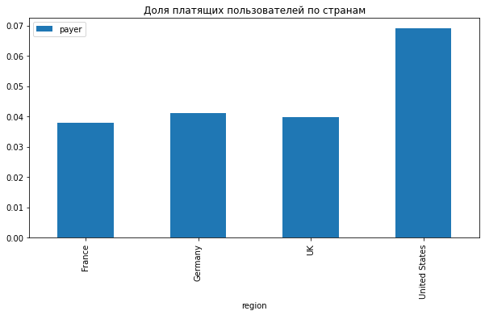

```python
group_by_region.plot(kind='bar', y='payer',x='region', figsize=(10,5), title='Доля платящих пользователей по странам')
plt.show()
```

```python
profiles['device'].value_counts() # Нашли какими устройствами пользуюся, всего 4 уникальных устройства
```

```
iPhone     54479
Android    35032
PC         30455
Mac        30042
Name: device, dtype: int64
```

```python
profiles.query('payer== True ').groupby('device').agg({'payer': 'count'}).sort_values('payer', ascending=False)
```

| device | payer |
| --- | --- |
| iPhone | 3382 |
| Android | 2050 |
| Mac | 1912 |
| PC | 1537 |

Сделал срез только по платящим пользователям, у них предпочтения в устройстве iPhone с отрывом

```python
group_by_device = profiles.groupby('device', as_index=False).agg({'payer':'mean', 'user_id': 'nunique'})
group_by_device.sort_values(by='payer', ascending= False)

group_by_device
```

|  | device | payer | user_id |
| --- | --- | --- | --- |
| 0 | Android | 0.06 | 35032 |
| 1 | Mac | 0.06 | 30042 |
| 2 | PC | 0.05 | 30455 |
| 3 | iPhone | 0.06 | 54479 |

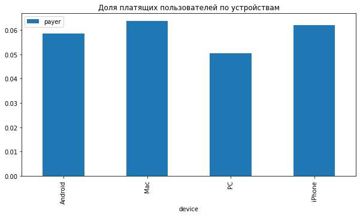

```python
group_by_device.plot(kind='bar', y='payer',x='device', figsize=(10,5), title='Доля платящих пользователей по устройствам');
```

Здесь мы видим что разница небольшая, но все равно доля платящих пользователей для устройст фирмы Apple, это Mac и iPhone выше чем у Android и PC

Определим каналы, из которых пришло больше всего платящих пользователей

```python
profiles.query('payer== True ').groupby('channel', as_index=False).agg({'payer': 'count'}).sort_values('payer', ascending=False)
```

|  | channel | payer |
| --- | --- | --- |
| 1 | FaceBoom | 3557 |
| 6 | TipTop | 1878 |
| 10 | organic | 1160 |
| 7 | WahooNetBanner | 453 |
| 0 | AdNonSense | 440 |
| 5 | RocketSuperAds | 352 |
| 2 | LeapBob | 262 |
| 4 | OppleCreativeMedia | 233 |
| 9 | lambdaMediaAds | 225 |
| 8 | YRabbit | 165 |
| 3 | MediaTornado | 156 |

Видим три канала привлечения, которые выделяются, если не брать во внимания канал Organic, так как это пользователи которые пришли сами то очевидный лидер здесь FaceBoom, также TipTop

```python
group_by_channel = profiles.groupby('channel', as_index=False).agg({'payer':'mean', 'user_id': 'nunique'})
group_by_channel.sort_values(by='payer', ascending= False)
```

|  | channel | payer | user_id |
| --- | --- | --- | --- |
| 1 | FaceBoom | 0.12 | 29144 |
| 0 | AdNonSense | 0.11 | 3880 |
| 9 | lambdaMediaAds | 0.10 | 2149 |
| 6 | TipTop | 0.10 | 19561 |
| 5 | RocketSuperAds | 0.08 | 4448 |
| 7 | WahooNetBanner | 0.05 | 8553 |
| 8 | YRabbit | 0.04 | 4312 |
| 3 | MediaTornado | 0.04 | 4364 |
| 2 | LeapBob | 0.03 | 8553 |
| 4 | OppleCreativeMedia | 0.03 | 8605 |
| 10 | organic | 0.02 | 56439 |

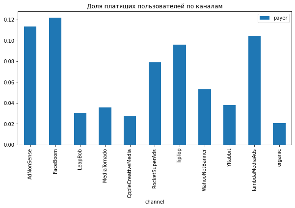

```python
group_by_channel.plot(kind='bar', y='payer',x='channel', figsize=(10,5), title='Доля платящих пользователей по каналам');
```

FaceBoom лидирует по общему количеству пользователей и по доли платящих пользователей. Надо обратить на этот канал особое внимание

### Маркетинг

- Посчитаем общую сумму расходов на маркетинг.
- Выясним, как траты распределены по рекламным источникам, то есть сколько денег потратили на каждый источник.
- Построим визуализацию динамики изменения расходов во времени (по неделям и месяцам) по каждому источнику.
- Узнаем, сколько в среднем стоило привлечение одного пользователя (CAC) из каждого источника. Используем профили пользователей.

```python
total_costs= costs['costs'].sum() # Общая сумма расходов на маркетинг
total_costs
```

```
105497.30000000002
```

```python
costs_by_channel= costs.groupby('channel', as_index=False).agg({'costs':'sum'}).sort_values(by = 'costs', ascending = False)
costs_by_channel
```

|  | channel | costs |
| --- | --- | --- |
| 6 | TipTop | 54751.30 |
| 1 | FaceBoom | 32445.60 |
| 7 | WahooNetBanner | 5151.00 |
| 0 | AdNonSense | 3911.25 |
| 4 | OppleCreativeMedia | 2151.25 |
| 5 | RocketSuperAds | 1833.00 |
| 2 | LeapBob | 1797.60 |
| 9 | lambdaMediaAds | 1557.60 |
| 3 | MediaTornado | 954.48 |
| 8 | YRabbit | 944.22 |

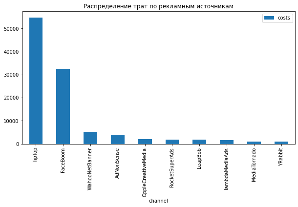

```python
costs_by_channel.plot(kind='bar', y='costs',x='channel', figsize=(10,5), title='Распределение трат по рекламным источникам');
```

Отдел маркетинга в основном делает ставку на два источника. Это TipTop и FaceBoom

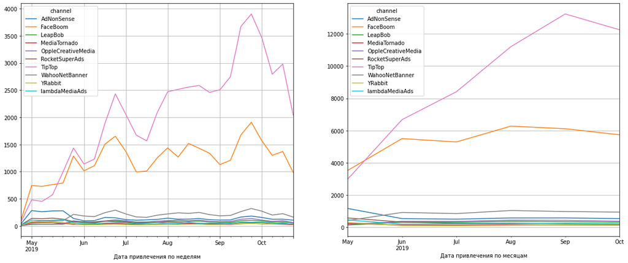

```python
plt.figure(figsize=(20, 8))
ax1 = plt.subplot(1, 2, 1)
costs['week'] = costs['dt'].astype('datetime64[W]')
costs.pivot_table(
    index='week', columns='channel', values='costs', aggfunc='sum').plot(grid=True, ax=ax1)
plt.xlabel('Дата привлечения по неделям')

ax2 = plt.subplot(1, 2, 2)
costs['month'] = costs['dt'].astype('datetime64[M]')
costs.pivot_table(
    index='month', columns='channel', values='costs', aggfunc='sum').plot(grid=True, ax=ax2)
plt.xlabel('Дата привлечения по месяцам')

plt.show()
```

```python
costs.pivot_table(index='week', columns='channel', values='costs', aggfunc='sum').head()
```

| channel week | AdNonSense | FaceBoom | LeapBob | MediaTornado | OppleCreativeMedia | RocketSuperAds | TipTop | WahooNetBanner | YRabbit | lambdaMediaAds |
| --- | --- | --- | --- | --- | --- | --- | --- | --- | --- | --- |
| 2019-04-25 | 40.95 | 113.30 | 2.52 | 6.24 | 4.25 | 21.06 | 80.00 | 10.80 | 8.10 | 17.60 |
| 2019-05-02 | 281.40 | 742.50 | 27.09 | 57.60 | 34.75 | 136.89 | 479.00 | 73.80 | 76.50 | 105.60 |
| 2019-05-09 | 259.35 | 728.20 | 29.61 | 59.76 | 31.00 | 131.62 | 451.00 | 93.00 | 74.10 | 98.40 |
| 2019-05-16 | 275.10 | 760.10 | 28.98 | 58.80 | 31.00 | 142.16 | 572.60 | 85.80 | 66.60 | 101.60 |
| 2019-05-23 | 277.20 | 788.70 | 30.45 | 46.56 | 44.00 | 122.85 | 993.70 | 95.40 | 60.00 | 116.00 |

```python
costs.pivot_table(index='month', columns='channel', values='costs', aggfunc='sum').head()
```

| channel month | AdNonSense | FaceBoom | LeapBob | MediaTornado | OppleCreativeMedia | RocketSuperAds | TipTop | WahooNetBanner | YRabbit | lambdaMediaAds |
| --- | --- | --- | --- | --- | --- | --- | --- | --- | --- | --- |
| 2019-05-01 | 1169.70 | 3524.40 | 140.28 | 238.56 | 169.75 | 577.98 | 2981.00 | 418.80 | 299.70 | 458.40 |
| 2019-06-01 | 538.65 | 5501.10 | 314.58 | 138.00 | 370.00 | 325.72 | 6675.60 | 921.00 | 106.20 | 199.20 |
| 2019-07-01 | 504.00 | 5294.30 | 313.53 | 138.48 | 366.50 | 252.07 | 8410.20 | 851.40 | 97.38 | 219.20 |
| 2019-08-01 | 579.60 | 6274.40 | 369.81 | 154.56 | 439.25 | 253.11 | 11202.00 | 1040.40 | 124.74 | 220.00 |
| 2019-09-01 | 581.70 | 6114.90 | 343.98 | 144.72 | 427.75 | 218.40 | 13232.50 | 977.40 | 152.79 | 247.20 |

Динамика изменеия расходов по времени говорит нам о том что больше всего расходов идет на каналы FaceBoom и TipTop. А пик расходов приходится на середину сентября

Средняя стоимость привлечения одного пользователя (CAC) из каждого источника

```python
group_by_cac = profiles.groupby('channel', as_index=False).agg({'acquisition_cost': 'mean'})
group_by_cac = group_by_cac.sort_values('acquisition_cost', ascending = False)
group_by_cac
```

|  | channel | acquisition_cost |
| --- | --- | --- |
| 6 | TipTop | 2.80 |
| 1 | FaceBoom | 1.11 |
| 0 | AdNonSense | 1.01 |
| 9 | lambdaMediaAds | 0.72 |
| 7 | WahooNetBanner | 0.60 |
| 5 | RocketSuperAds | 0.41 |
| 4 | OppleCreativeMedia | 0.25 |
| 8 | YRabbit | 0.22 |
| 3 | MediaTornado | 0.22 |
| 2 | LeapBob | 0.21 |
| 10 | organic | 0.00 |

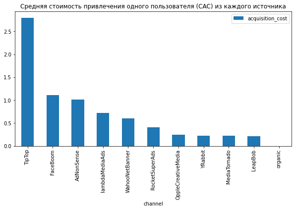

```python
group_by_cac.plot(kind='bar', y='acquisition_cost',x='channel', figsize=(10,5),
                  title='Средняя стоимость привлечения одного пользователя (CAC) из каждого источника')
plt.show()
```

Каждый привлеченный пользователь из TipTop стоит компании очень дорого, в несколько раз дороже чем из других компаний. Надо пересмотреть маркетинговую стратегию

ROI для каждого источника

```python
revenue_id=orders.groupby('user_id', as_index=False).agg({'revenue':'sum'})
revenue_id
users_revenue=revenue_id.merge(profiles, on='user_id')
channel_revenue=users_revenue.groupby('channel', as_index=False).agg({'revenue':'sum'})
channel_revenue
channel_cost= costs.groupby('channel', as_index=False).agg({'costs':'sum'})
channel_roi= channel_cost.merge(channel_revenue, on='channel')
channel_roi['roi']=channel_roi['revenue']/channel_roi['costs']
channel_roi=channel_roi.sort_values('roi')
channel_roi
```

|  | channel | costs | revenue | roi |
| --- | --- | --- | --- | --- |
| 1 | FaceBoom | 32445.60 | 25637.66 | 0.79 |
| 0 | AdNonSense | 3911.25 | 3697.17 | 0.95 |
| 6 | TipTop | 54751.30 | 69574.76 | 1.27 |
| 7 | WahooNetBanner | 5151.00 | 20006.63 | 3.88 |
| 4 | OppleCreativeMedia | 2151.25 | 8365.53 | 3.89 |
| 2 | LeapBob | 1797.60 | 9560.13 | 5.32 |
| 9 | lambdaMediaAds | 1557.60 | 8941.70 | 5.74 |
| 3 | MediaTornado | 954.48 | 5752.32 | 6.03 |
| 5 | RocketSuperAds | 1833.00 | 11598.32 | 6.33 |
| 8 | YRabbit | 944.22 | 6201.43 | 6.57 |

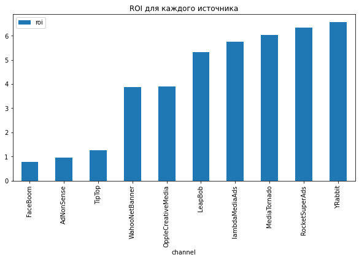

```python
channel_roi.plot(kind='bar', y='roi',x='channel', figsize=(10,5),
                  title='ROI для каждого источника')
plt.show()
```

График сам говорит за себя, здесь и комментировать нечего. Три явных аутсайдера

### Оценка окупаемости рекламы

Используя графики LTV, ROI и CAC, проанализируем окупаемость рекламы. Считаем, что на календаре 1 ноября 2019 года, а в бизнес-плане заложено, что пользователи должны окупаться не позднее чем через две недели после привлечения.

```python
observation_date = datetime(2019, 11, 1).date()  # момент анализа 1 ноября 2019
horizon_days = 14  # горизонт анализа
```

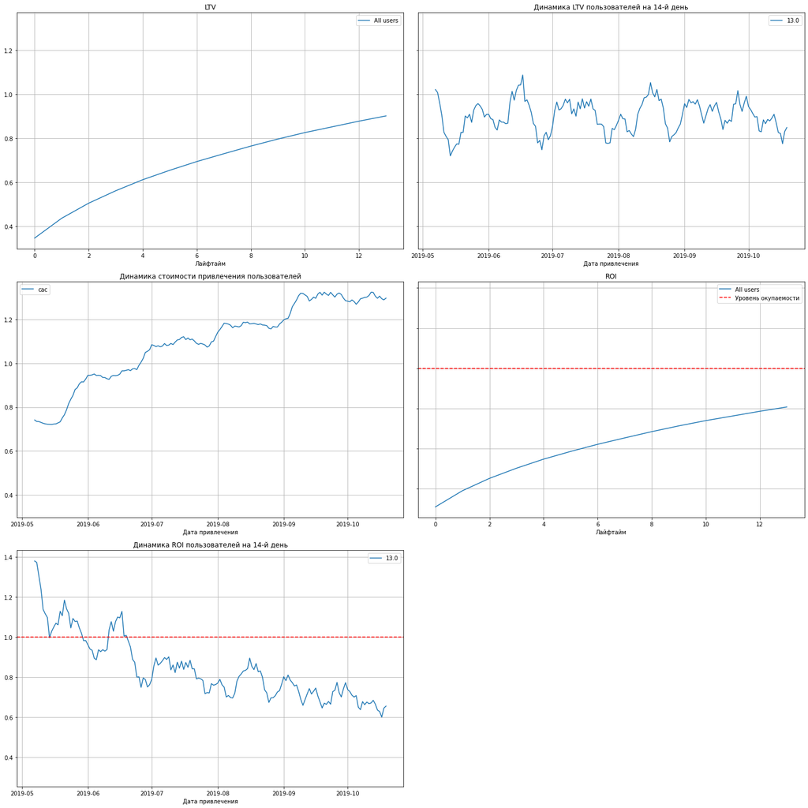

```python
# считаем LTV и ROI без учета органических пользователей
ltv_raw, ltv_grouped, ltv_history, roi_grouped, roi_history = get_ltv(
    profiles.query('channel != "organic" '), orders, observation_date, horizon_days
)

# строим графики
plot_ltv_roi(ltv_grouped, ltv_history, roi_grouped, roi_history,horizon_days)
```

График LTV имеет стандыртый вид и с течением времени увеличивается.Динамика стоимости привлечения за выбранный горизонт только растет.По графику ROI видно что привлечение пользователей еще не успело окупится и график кривой не дошел до уровня окупаемости.Динамика ROI показывает что эффект от рекламы в первые недели был хорошо заметен потом начал снижаться со временем.

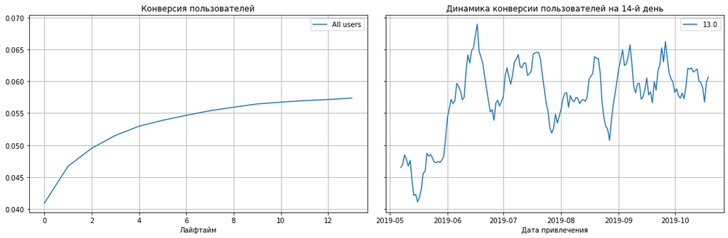

```python
# Построим графики конверсии и динамики конверсии

conversion_raw, conversion, conversion_history = get_conversion(
    profiles, orders, observation_date, horizon_days)

plot_conversion(conversion, conversion_history, horizon_days)
```

Конверсия со временем растет а динамика конверсии колеблится со временем. Пользователи привлеченные в мае и в начале июня показывали слабую динамику по конверсии.Потом она стала чуть выше с пиками роста и падения

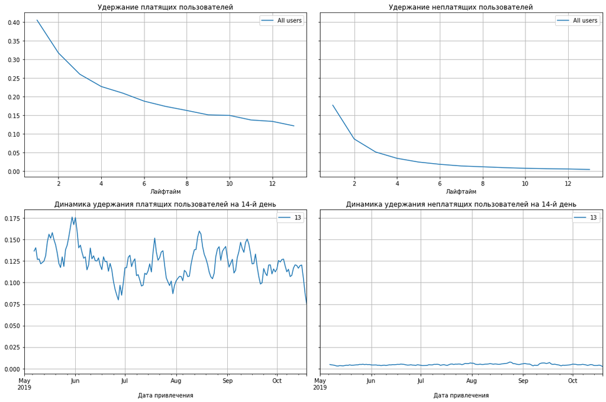

```python
# Построим кривые удержания и динамики удержания по платящим и неплатящим пользователям

result_raw, result_grouped, result_in_time = get_retention( profiles, visits,observation_date, 14)
plot_retention(result_grouped, result_in_time, 14)
```

Если разделить пользователей по платящим и не платящим то видно что удержание платящих намного выше, а динамика удержания неплатящих имеет почти прямой вид без резких шумов

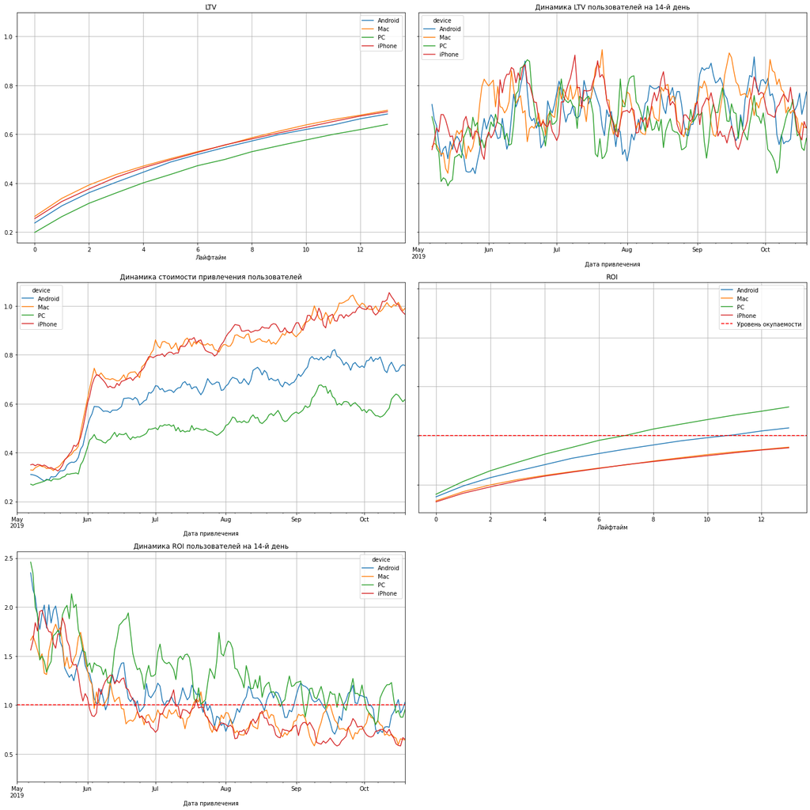

```python
# Проанализируем окупаемость рекламы с разбивкой по устройствам.Построим графики

# считаем LTV и ROI
ltv_raw, ltv_grouped, ltv_history, roi_grouped, roi_history = get_ltv(
    profiles, orders, observation_date, horizon_days, dimensions=['device']
)

# строим графики
plot_ltv_roi(ltv_grouped, ltv_history, roi_grouped, roi_history,horizon_days)
```

График LTV имеет примерно равный вид ля всех устройст, однако пользователи PC немного отстают Динамика LTV пользователей примерно одинаковая но чуть выше у Mac и iPhone. Динамика стоимости привлечения пользователей выше у пользователей продукции Apple, а вот уровня окупаемости за две недели они не достигли, Здесь окупились пользователи Android и PC Динамика ROI новых пользователей с горизонтом 14 дней была выше в начале мая, а потом плавномерно снижалась, это касается всех устройст.

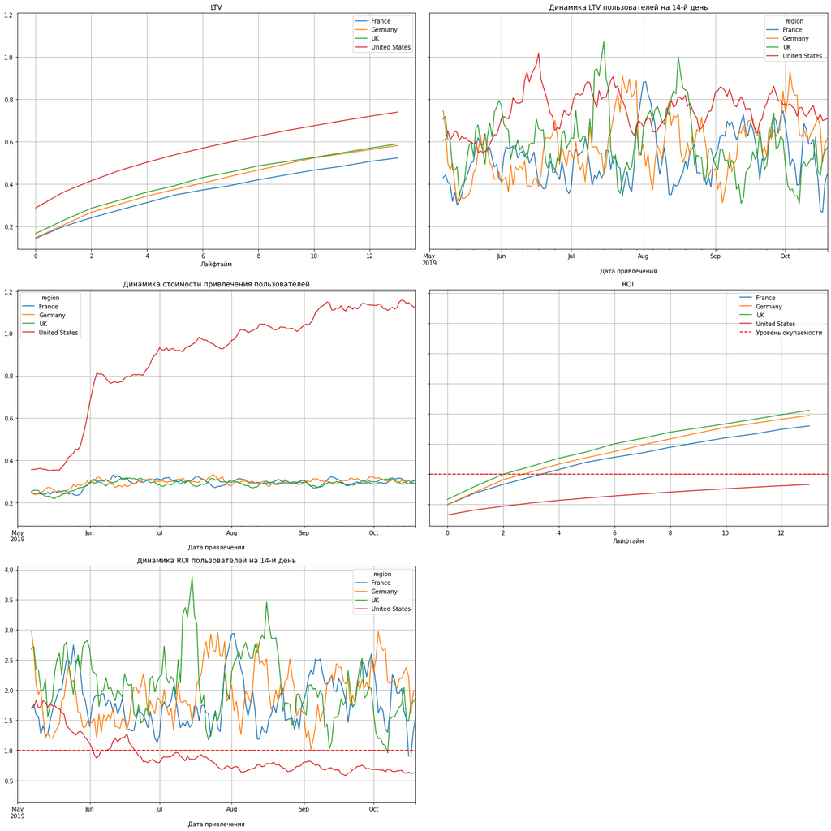

```python
# Проанализируем окупаемость рекламы с разбивкой по странам.

# считаем LTV и ROI
ltv_raw, ltv_grouped, ltv_history, roi_grouped, roi_history = get_ltv(
    profiles, orders, observation_date, horizon_days, dimensions=['region']
)

# строим графики
plot_ltv_roi(ltv_grouped, ltv_history, roi_grouped, roi_history,horizon_days)
```

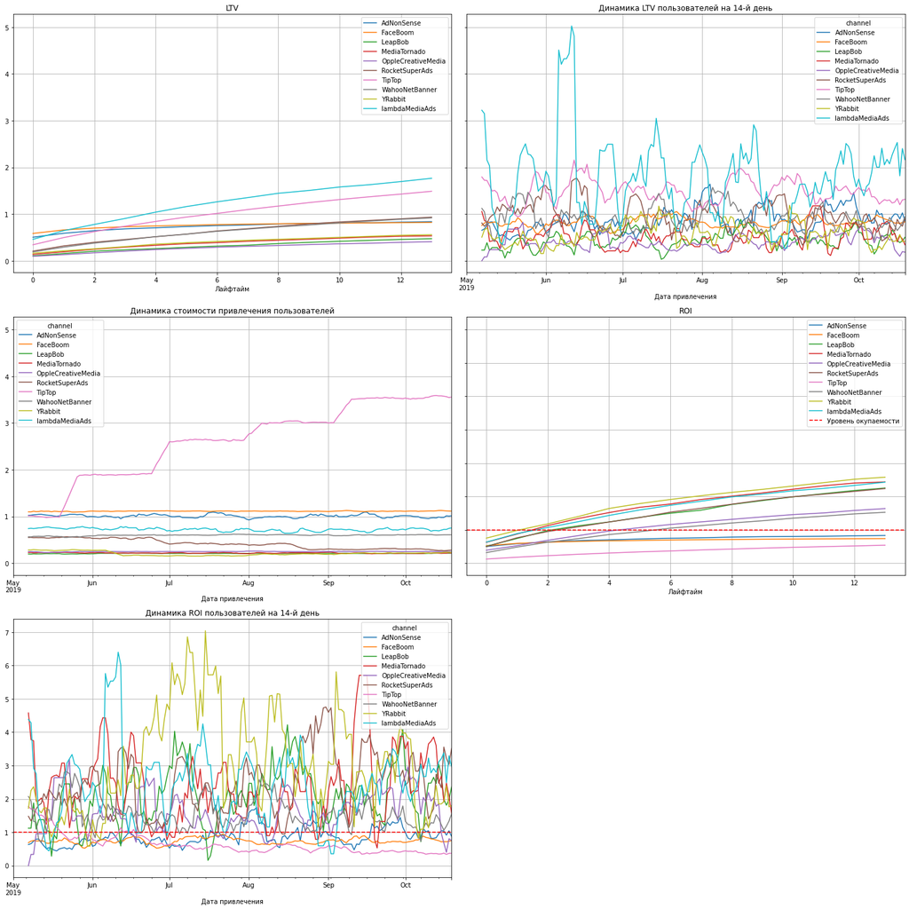

```python
# Проанализируем окупаемость рекламы с разбивкой по рекламным каналам без учета органических  пользователей

# считаем LTV и ROI
ltv_raw, ltv_grouped, ltv_history, roi_grouped, roi_history = get_ltv(
    profiles.query('channel != "organic" '), orders, observation_date, horizon_days, dimensions=['channel']
)

# строим графики
plot_ltv_roi(ltv_grouped, ltv_history, roi_grouped, roi_history,horizon_days)
```

LTV больше всего от пользователей, привлеченных через каналы lambdaMediaAds и TipTop. Динамика LTV в целом выше у lambdaMediaAds, в целом у всех рекламных каналов динамика с пиками роста и падения. Динамика стоимости привлечения пользлвателей у всех более менее ровная кроме канала TipTop, он сильно отличается,и со временем динамика только растет. Большинство пользователей с каналов окупились, кроме таких каналов привлечения как TipTop, FaceBoom , AdNonSense Кривые динамики окупаемости пользователей с каналов TipTop и FaceBoom находятся ниже уровня окупаемости на всем протяжении, надо об этом всерьез задуматься.

1. Чтобы ответить на первый вопрос: Окупается ли реклама, направленная на привлечение пользователей в целом? посчитаем общие расходы на рекламу, общие доходы, соотнесем эти два показателя и получим ROI

```python
channel_roi
```

[output not shown]

```python
roi_average= channel_roi['revenue'].sum()/channel_roi['costs'].sum()
roi_average
```

```
1.605118330042579
```

В целом можно сказать что расходы на рекламу окупаются более чем в полтора раза

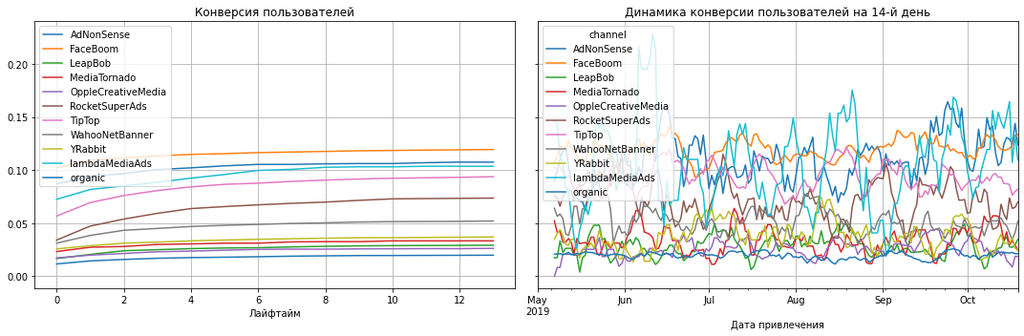

```python
# Построим графики конверсии и динамики конверсии по каналам

conversion_raw, conversion, conversion_history = get_conversion(
    profiles, orders, observation_date,horizon_days,dimensions=['channel'])

plot_conversion(conversion,conversion_history,horizon_days)
```

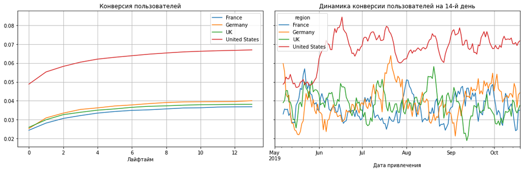

```python
# Построим графики конверсии и динамики конверсии по странам

conversion_raw, conversion, conversion_history = get_conversion(
    profiles, orders, observation_date,horizon_days,dimensions=['region'])

plot_conversion(conversion,conversion_history,horizon_days)
```

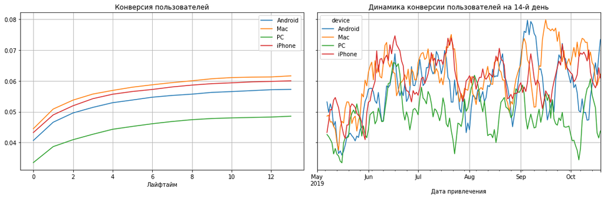

```python
# Построим графики конверсии и динамики конверсии по устройствам

conversion_raw, conversion, conversion_history = get_conversion(
    profiles, orders, observation_date,horizon_days,dimensions=['device'])

plot_conversion(conversion,conversion_history,horizon_days)
```

Вывод: Конверсия выше у MAC и iPhone, у США , а также у рекламного канала FaceBoom

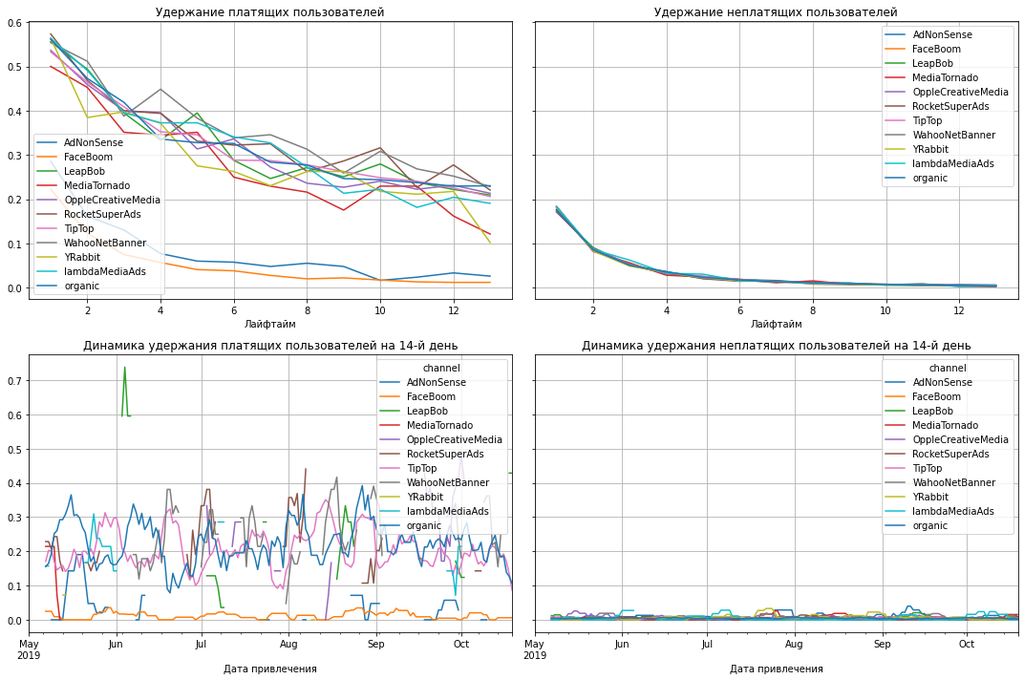

```python
# Построим кривые удержания и динамики удержания по платящим и неплатящим пользователям

result_raw, result_grouped, result_in_time = get_retention( profiles, visits,observation_date, 14,dimensions=['channel'])
plot_retention(result_grouped, result_in_time, 14)
```

Если брать платящих пользователей, то меньше всего удержание у AdNonSense и FaceBoom, у неплатщих кривые почти одинаковые

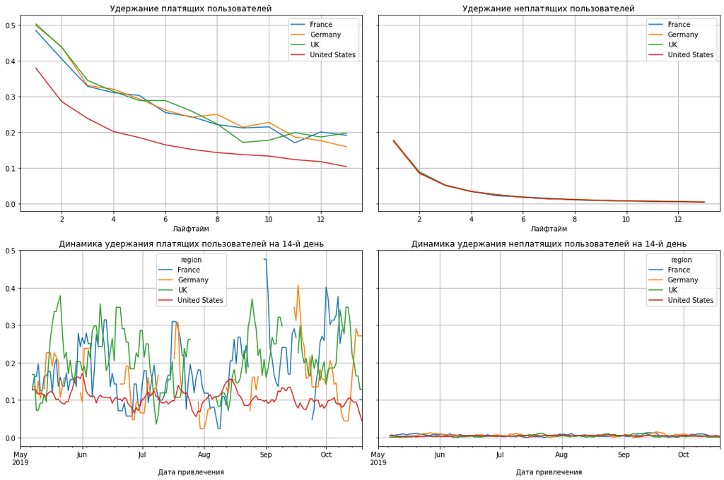

```python
# Построим кривые удержания и динамики удержания по платящим и неплатящим пользователям

result_raw, result_grouped, result_in_time = get_retention( profiles, visits,observation_date, 14,dimensions=['region'])
plot_retention(result_grouped, result_in_time, 14)
```

Если брать платящих пользователей, то меньше всего удержание США, у неплатщих кривые почти одинаковые

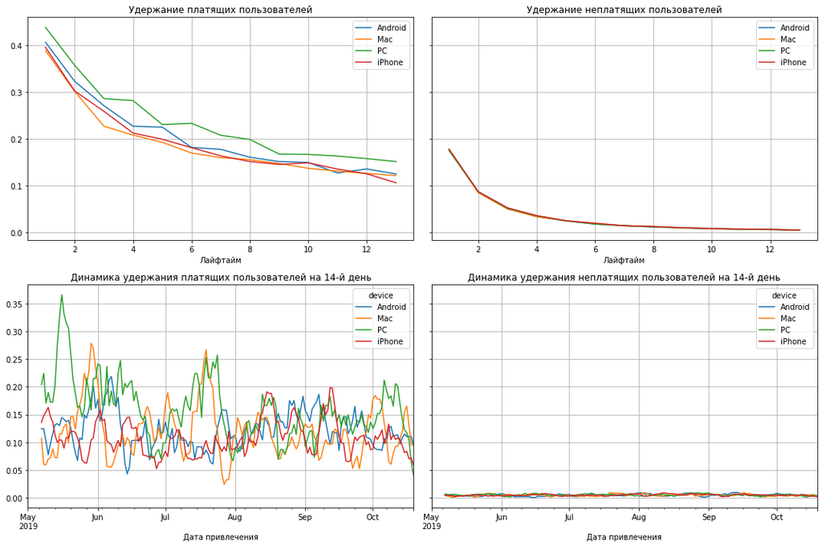

```python
# Построим кривые удержания и динамики удержания по платящим и неплатящим пользователям

result_raw, result_grouped, result_in_time = get_retention( profiles, visits,observation_date, 14,dimensions=['device'])
plot_retention(result_grouped, result_in_time, 14)
```

Если брать платящих пользователей, то меньше всего удержание у Mac и iPhone, у неплатщих кривые почти одинаковые

1. Большинство пользователей с каналов окупились, кроме таких каналов привлечения как TipTop, FaceBoom , AdNonSense. Они оказывают негативное влияние, я бы рекомендовал от них избавляться Что касается стран, то пользователи из США не окупаются так как расходы на рекламу у них очень высокие. Пользователи устройст Mac и iPhone не успели окупиться за 2 недели
1. Проблемы окупаемости могут быть вызваны плохим выбором каналов привлечения рекламы а также большими затратами на саму рекламу, а также выбором устройст на которых можно сделать акцент для развития приложения. Можно попробовать развивать приложение в других регионах

**Вывод:**

1. Ошибки в выборе каналов на начальном этапе, предварительный анализ показателей рекламных каналов перед заключением с ними договора на рекламные услуги. Большие расходы на саму рекламу. Не оптимальный выбор регионов развития для приложения. Я бы не стал здесь всю вину накладывать на отдел маркетинга, возможно само приложение следует доработать,и улучшить его характеристики, чтобы пользователи активнее совершали покупки
1. Отделу маркетинга рекомендую избавиться от каналов привлечения, которые не доходят уровня окупаемости и оптимизировать расходы на рекламу, и будет всем счастье. Спасибо за внимание.